# Exploratory Data Analysis on My 2005 Ford F150

Dusty Turner

June 12, 2018

In February 2006, my dad and I split the cost of a 2005 Ford F150. He probably paid the larger half, but I believe he (and I) have got our money’s worth out of it as I still drive it to this day. Since the purchase, I have tracked the gas milage every time I’ve filled up the tank. This tutorial uses this data set to highlight some functions in R to do the following:

- Exploratory Data Analysis
- Explore Dates in R
- Build a Linear Model
- Build a Time Series Prediction

I will echo all the R code, messages, and warnings in this tutorial so you can see what output to expect if you do similar analysis on your own data.

## Tidyverse

Most commands from this tutorial will be called from the tidyverse. Thank you [Hadley Wickham](http://hadley.nz/)

```r
library(tidyverse)
```

## A Little About Dates in R

Before we launch into analysisng the data, we should go over a few important facts about dates in R.

There are 3 date/time classes are built in to R  
- Date  
- POSIXct  
- POSIXlt

### Base R

First, base R can read a string of text and conver it to a date class. To help it read the date, you must tell R what date format your character string should expect. Below are several examples. You can look at all the possible format and codes by running `?strptime` in your R console.

```r
strptime("October 16, 1984", format = "%B %e, %Y")
```

```
## [1] "1984-10-16 EDT"
```

```r
strptime("16 October, 1984", format = "%e %B, %Y")
```

```
## [1] "1984-10-16 EDT"
```

```r
strptime("16-- October, 1984", format = "%e-- %B, %Y")
```

```
## [1] "1984-10-16 EDT"
```

```r
class(strptime("16-- October, 1984", format = "%e-- %B, %Y"))
```

```
## [1] "POSIXlt" "POSIXt"
```

```r
birthday = strptime("16-- October, 1984", format = "%e-- %B, %Y")
```

As you can see, the `strptime` command has R recognzie your string as a `POSIXlt POSIXt` class.

## lubridate

A second and easier way to have R reconginze dates is to use the `lubridate` package in R. Thanks again [Hadley](http://hadley.nz/)

```r
library(lubridate)
```

Using `lubridate` also allows R to read character strings as dates. However, instead of having to tell R the exact format of your string (which can be difficult), lubridate tries many mothods to recognzie your string. You simply provide it the order of your month, day, and year in `ymd` format or any combination thereof.

```r
mdy("June 14, 2018")
```

```
## [1] "2018-06-14"
```

```r
dmy("14 June, 2018")
```

```
## [1] "2018-06-14"
```

```r
dmy("14-- June, 2018")
```

```
## [1] "2018-06-14"
```

```r
class(dmy("14-- June, 2018"))
```

```
## [1] "Date"
```

You’ll notice that lubridate creats a `date` class. To change it into `POSIXlt POSIXt` format, wrap your text with the following code.

```r
class(as.POSIXlt(mdy("June 14, 2018")))
```

```
## [1] "POSIXlt" "POSIXt"
```

We also need to ensure our date is the correct timezone. This would be more important if our date had a time included.

```r
date = as.POSIXlt(dmy("14 June, 2018"))
date
```

```
## [1] "2018-06-14 UTC"
```

```r
date = force_tz(date, tzone = "America/New_York")
date
```

```
## [1] "2018-06-14 EDT"
```

When a date vector is of class `as.POSIXlt`, all the information is stored as a list. You can also extract specific information from the list as well.

```r
date
```

```
## [1] "2018-06-14 EDT"
```

```r
unlist(date)
```

```
##      sec      min     hour     mday      mon     year     wday     yday
##      "0"      "0"      "0"     "14"      "5"    "118"      "4"    "164"
##    isdst     zone   gmtoff
##      "1"    "EDT" "-14400"
```

```r
date$mon
```

```
## [1] 5
```

```r
month(date)
```

```
## [1] 6
```

```r
date$year
```

```
## [1] 118
```

```r
year(date)
```

```
## [1] 2018
```

You can manipulate these date vectors as well.

```r
date - birthday
```

```
## Time difference of 12294 days
```

```r
birthday + hours(4)
```

```
## [1] "1984-10-16 04:00:00 UTC"
```

```r
birthday + days(4)
```

```
## [1] "1984-10-20 UTC"
```

```r
date + years(4) + months(9)
```

```
## [1] "2023-03-14 EDT"
```

## Exploratory Data Analysis

Now, lets look at the dataset

We will use the following functions:

- `head`
- `skim` function from the `skimr` package

### Read in Data

```r
truck = read_csv("FordF150.csv")
```

### Explore

```r
head(truck)
```

```
## # A tibble: 6 x 7
##   FillUpDate TotalMiles TankMiles Gallons   MPG FinishTankDate Notes
##   <chr>           <dbl>     <dbl>   <dbl> <dbl> <chr>          <chr>
## 1 17-Feb-06      24251       366     22.6  16.2 18-Feb-06      <NA>
## 2 18-Feb-06      24443.      192.    12.8  15.0 18-Feb-06      <NA>
## 3 18-Feb-06      24765       322.    16.5  19.5 27-Feb-06      <NA>
## 4 27-Feb-06      25156       391     24.9  15.7 10-Mar-06      <NA>
## 5 10-Mar-06      25431.      275.    15.8  17.4 11-Mar-06      <NA>
## 6 11-Mar-06      25548.      117.     7.5  15.6 11-Mar-06      <NA>
```

Below the names of each column, r is telling us the data type. We can already tell we will need to change some characters to dates and others to numeric.

Its a good practice to ensure all the names of your data are in the same format. Lets use the `janitor` package and the `clean_names` function. This ensures that the names are unique, consistant, have no non alpha-numeric characters, and transform spaces into underscores.

```r
truck =
truck %>%
janitor::clean_names(case = "snake")

truck
```

```
## # A tibble: 420 x 7
##    fill_up_date total_miles tank_miles gallons   mpg finish_tank_date
##    <chr>              <dbl>      <dbl>   <dbl> <dbl> <chr>
##  1 17-Feb-06         24251        366     22.6  16.2 18-Feb-06
##  2 18-Feb-06         24443.       192.    12.8  15.0 18-Feb-06
##  3 18-Feb-06         24765        322.    16.5  19.5 27-Feb-06
##  4 27-Feb-06         25156        391     24.9  15.7 10-Mar-06
##  5 10-Mar-06         25431.       275.    15.8  17.4 11-Mar-06
##  6 11-Mar-06         25548.       117.     7.5  15.6 11-Mar-06
##  7 11-Mar-06         25900.       352.    18.8  18.7 12-Mar-06
##  8 12-Mar-06         26283.       382.    22.1  17.3 13-Mar-06
##  9 13-Mar-06         26617.       334     19    17.6 14-Mar-06
## 10 14-Mar-06         26847.       230.    13.7  16.8 14-Mar-06
## # ... with 410 more rows, and 1 more variable: notes <chr>
```

### Lets explor the data from the `skimr` package.

```r
library(skimr)
skim(truck)
```

```
## Skim summary statistics
##  n obs: 420
##  n variables: 7
##
## Variable type: character
##          variable missing complete   n min max empty n_unique
##      fill_up_date       0      420 420   8   9     0      392
##  finish_tank_date       1      419 420   8   9     0      388
##             notes     395       25 420   9  44     0        6
##
## Variable type: numeric
##     variable missing complete   n      mean       sd       p0      p25
##      gallons       1      419 420     25.54     5.78     6.06    22.53
##          mpg       1      419 420     15.48     2.07     8.39    14.61
##   tank_miles       1      419 420    394.55    98.98    93.6    336
##  total_miles       0      420 420 105651.72 47798.53 23885    63729.65
##        p50       p75      p100     hist
##      27.3      29.69     39.4  ▁▁▂▂▅▇▃▁
##      15.64     16.55     25.83 ▁▁▅▇▂▁▁▁
##     416.3     460.25    799.6  ▁▂▃▇▆▁▁▁
##  107926.75 145122.65 189161.7  ▇▆▆▆▇▇▆▆
```

This is more informative. The `skim` function shows us the total number of observations and variables, missingness, despcriptive statistics, and a general distribution of the data.

### Filter NAs

There are a couple of `NA`s in the data. They happen to all be in the same row so we can handle them with the following command

```r
truck = truck %>%
  filter(!is.na(gallons))
truck
```

```
## # A tibble: 419 x 7
##    fill_up_date total_miles tank_miles gallons   mpg finish_tank_date
##    <chr>              <dbl>      <dbl>   <dbl> <dbl> <chr>
##  1 17-Feb-06         24251        366     22.6  16.2 18-Feb-06
##  2 18-Feb-06         24443.       192.    12.8  15.0 18-Feb-06
##  3 18-Feb-06         24765        322.    16.5  19.5 27-Feb-06
##  4 27-Feb-06         25156        391     24.9  15.7 10-Mar-06
##  5 10-Mar-06         25431.       275.    15.8  17.4 11-Mar-06
##  6 11-Mar-06         25548.       117.     7.5  15.6 11-Mar-06
##  7 11-Mar-06         25900.       352.    18.8  18.7 12-Mar-06
##  8 12-Mar-06         26283.       382.    22.1  17.3 13-Mar-06
##  9 13-Mar-06         26617.       334     19    17.6 14-Mar-06
## 10 14-Mar-06         26847.       230.    13.7  16.8 14-Mar-06
## # ... with 409 more rows, and 1 more variable: notes <chr>
```

### Transform Variable Types

```r
truck = truck %>%
  mutate(fill_up_date = force_tz(dmy(fill_up_date), "America/New_York")) %>%
  mutate(finish_tank_date = force_tz(dmy(finish_tank_date), "America/New_York")) %>%
  mutate(total_miles = as.numeric(total_miles)) %>%
  mutate(notes = ifelse(is.na(notes),0,1))
truck
```

```
## # A tibble: 419 x 7
##    fill_up_date total_miles tank_miles gallons   mpg finish_tank_date
##    <date>             <dbl>      <dbl>   <dbl> <dbl> <date>
##  1 2006-02-17        24251        366     22.6  16.2 2006-02-18
##  2 2006-02-18        24443.       192.    12.8  15.0 2006-02-18
##  3 2006-02-18        24765        322.    16.5  19.5 2006-02-27
##  4 2006-02-27        25156        391     24.9  15.7 2006-03-10
##  5 2006-03-10        25431.       275.    15.8  17.4 2006-03-11
##  6 2006-03-11        25548.       117.     7.5  15.6 2006-03-11
##  7 2006-03-11        25900.       352.    18.8  18.7 2006-03-12
##  8 2006-03-12        26283.       382.    22.1  17.3 2006-03-13
##  9 2006-03-13        26617.       334     19    17.6 2006-03-14
## 10 2006-03-14        26847.       230.    13.7  16.8 2006-03-14
## # ... with 409 more rows, and 1 more variable: notes <dbl>
```

### Lets look at some descriptive statistics

Largest Fill Up

```r
truck %>%
  filter(gallons > 32) %>%
  arrange(desc(gallons)) %>%
  print(n = Inf)
```

```
## # A tibble: 34 x 7
##    fill_up_date total_miles tank_miles gallons   mpg finish_tank_date
##    <date>             <dbl>      <dbl>   <dbl> <dbl> <date>
##  1 2011-09-30       101539        530.    39.4  13.4 2011-10-01
##  2 2017-08-24       186333.       467.    34.6  13.5 2017-10-16
##  3 2016-01-28       176148.       445.    34.4  12.9 2016-02-16
##  4 2017-03-05       184549        506.    34.2  14.8 2017-04-15
##  5 2012-09-07       126389.       392.    34.2  11.5 2012-09-11
##  6 2015-09-16       172403.       564.    33.6  16.8 2015-10-06
##  7 2017-10-16       186735.       402.    33.6  12.0 2017-10-21
##  8 2015-08-05       169828        527.    33.5  15.7 2015-08-07
##  9 2015-12-05       175259.       568.    33.5  17.0 2016-01-12
## 10 2016-02-16       176610.       461.    33.4  13.8 2016-02-22
## 11 2010-05-01        78328.       538.    33.4  16.1 2010-05-08
## 12 2008-06-24        53361.       465     33.4  13.9 2008-07-04
```

[output cut: 23 more lines]

Most MPG

```r
truck %>%
  arrange(desc(mpg)) %>%
  print(n = 20)
```

```
## # A tibble: 419 x 7
##    fill_up_date total_miles tank_miles gallons   mpg finish_tank_date
##    <date>             <dbl>      <dbl>   <dbl> <dbl> <date>
##  1 2007-07-24        39443.       485.    18.8  25.8 2007-07-24
##  2 2018-04-26       188965.       800.    31.5  25.4 2018-05-28
##  3 2016-08-10       182854.       558.    24.9  22.4 2016-10-05
##  4 2013-09-20       141542        492.    22.8  21.6 2013-10-07
##  5 2006-03-15        27825.       478.    22.8  21.0 2006-04-26
##  6 2012-08-09       121019.       342.    16.7  20.5 2012-08-15
##  7 2012-08-15       121361.       342.    16.7  20.5 2012-08-16
##  8 2012-08-04       120676.       298     14.6  20.5 2012-08-09
##  9 2012-06-08       116914.       348.    17.2  20.2 2012-06-15
## 10 2006-02-18        24765        322.    16.5  19.5 2006-02-27
## 11 2012-09-28       128298.       479.    24.7  19.4 2012-10-02
## 12 2007-06-11        35698.       212.    11.1  19.2 2007-06-28
## 13 2006-03-14        27238.       392.    20.5  19.1 2006-03-15
## 14 2012-05-04       114343.       336.    17.7  19.0 2012-05-07
## 15 2008-04-01        49952.       540.    28.5  19.0 2008-04-09
## 16 2007-06-11        35485.       429     22.9  18.8 2007-06-11
## 17 2007-07-30        41478.       473.    25.2  18.8 2007-08-04
## 18 2006-03-11        25900.       352.    18.8  18.7 2006-03-12
## 19 2015-07-20       168776.       526.    28.6  18.4 2015-07-21
## 20 2014-09-29       161178.       524.    28.7  18.3 2014-10-02
## # ... with 399 more rows, and 1 more variable: notes <dbl>
```

Least MPG

```r
truck %>%
  arrange(mpg) %>%
  print(n = 20)
```

```
## # A tibble: 419 x 7
##    fill_up_date total_miles tank_miles gallons   mpg finish_tank_date
##    <date>             <dbl>      <dbl>   <dbl> <dbl> <date>
##  1 2012-09-04       125393.       183     21.8  8.39 2012-09-05
##  2 2017-02-16       184043.       230     26.7  8.62 2017-03-05
##  3 2012-09-13       127295.       227.    26.2  8.69 2012-09-14
##  4 2017-01-09       183813.       248.    27.4  9.04 2017-02-16
##  5 2012-06-15       117119.       205.    22.6  9.07 2012-06-19
##  6 2012-09-13       127068.       166.    17.6  9.43 2012-09-13
##  7 2016-05-27       180674.       145.    15.0  9.69 2016-05-27
##  8 2018-01-31       187962.       310.    32    9.70 2018-02-22
##  9 2017-04-15       184833.       284.    28.8  9.86 2017-05-19
## 10 2016-10-05       183168        314.    30.5 10.3  2016-11-09
## 11 2018-05-28       189162.       197.    18.5 10.6  2018-06-29
## 12 2018-02-22       188165.       203.    19.0 10.7  2018-04-26
## 13 2012-11-19       131947.       159.    14.7 10.9  2012-11-20
## 14 2017-05-19       185182.       349.    31.6 11.0  2017-06-12
## 15 2012-09-05       125997.       336.    29.8 11.2  2012-09-07
## 16 2017-12-02       187652.       314.    27.6 11.4  2018-01-31
## 17 2006-03-15        27347.       108.     9.5 11.4  2006-03-15
## 18 2007-05-26        31747.       312.    27.3 11.4  2007-05-28
## 19 2012-09-07       126389.       392.    34.2 11.5  2012-09-11
## 20 2012-12-30       133927        241.    20.7 11.6  2013-01-04
## # ... with 399 more rows, and 1 more variable: notes <dbl>
```

View My Travel By Fillup

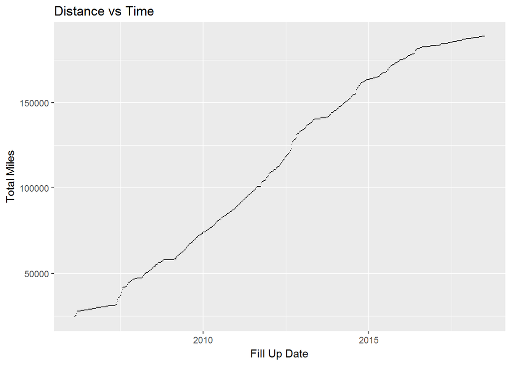

```r
truck %>%
  ggplot(aes(x = fill_up_date, y = total_miles)) +
  geom_segment(aes(x=fill_up_date, xend=finish_tank_date, yend = total_miles)) +
  ggtitle("Distance vs Time") + labs(x = "Fill Up Date", y = "Total Miles")
```

Since I placed a note in my data when I was uncertain of the miles filled up, lets color each observation by uncertainty.

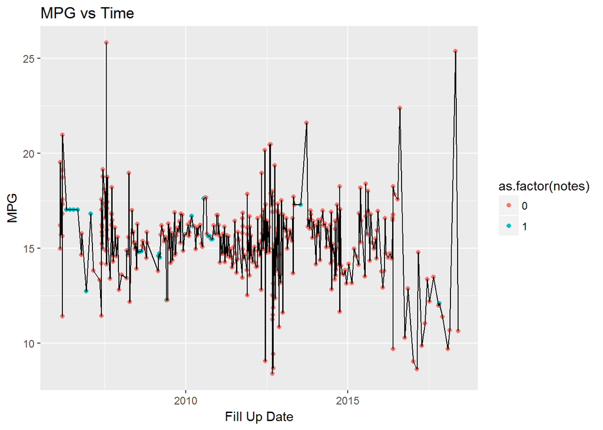

```r
truck %>%
  ggplot(aes(x = fill_up_date, y = mpg)) +
  geom_point(aes(color = as.factor(notes)))+
  geom_line() +
  ggtitle("MPG vs Time") + labs(x = "Fill Up Date", y = "MPG")
```

Also, to highlight an interactive tool, we’ll use the plotly library. This adds the ability to interact with the graphics in many ways which you can explore below. To do this, simply wrap your ggplot object in the `ggplotly command`

```r
library(plotly)
plot =
truck %>%
  ggplot(aes(x = fill_up_date, y = total_miles)) +
  geom_segment(aes(x=fill_up_date, xend=finish_tank_date, yend = total_miles)) +
  ggtitle("Distance vs Time")

ggplotly(plot)
```

[interactive chart not shown]

## Linear Model

We might also find it interesting to determine what factors impact the miles per gallon. This skips the iterative model building process, but its interesting to see what two factors have the most impact.

```r
options(scipen = 999) ## to remove scientific notation
lin.mod = lm(mpg~tank_miles+total_miles,data = truck)
summary(lin.mod)
```

```
##
## Call:
## lm(formula = mpg ~ tank_miles + total_miles, data = truck)
##
## Residuals:
##     Min      1Q  Median      3Q     Max
## -4.9633 -1.0774 -0.1609  0.9164  8.8338
##
## Coefficients:
##                 Estimate   Std. Error t value             Pr(>|t|)
## (Intercept) 12.695874099  0.399157850  31.807 < 0.0000000000000002 ***
## tank_miles   0.009672571  0.000890384  10.863 < 0.0000000000000002 ***
## total_miles -0.000009789  0.000001848  -5.297          0.000000191 ***
## ---
## Signif. codes:  0 '***' 0.001 '**' 0.01 '*' 0.05 '.' 0.1 ' ' 1
##
## Residual standard error: 1.797 on 416 degrees of freedom
## Multiple R-squared:  0.2496, Adjusted R-squared:  0.246
## F-statistic: 69.19 on 2 and 416 DF,  p-value: < 0.00000000000000022
```

As you can see, the more miles I drove on a tank, the more miles per gallon I should expect. For every extra mile I drive on a tank of gas, I should expect to receive about ~.01 more miles per gallon.

Also, for every mile I’ve driven total on my car, I should expect to receive ~.00001 miles per gallon less. My layman’s interpretation of this is tha tas my truck gets older, it gets worse gas mileage on average.

For completeness’s sake, we should look at the residuals to assess our assumptions for linear regression:

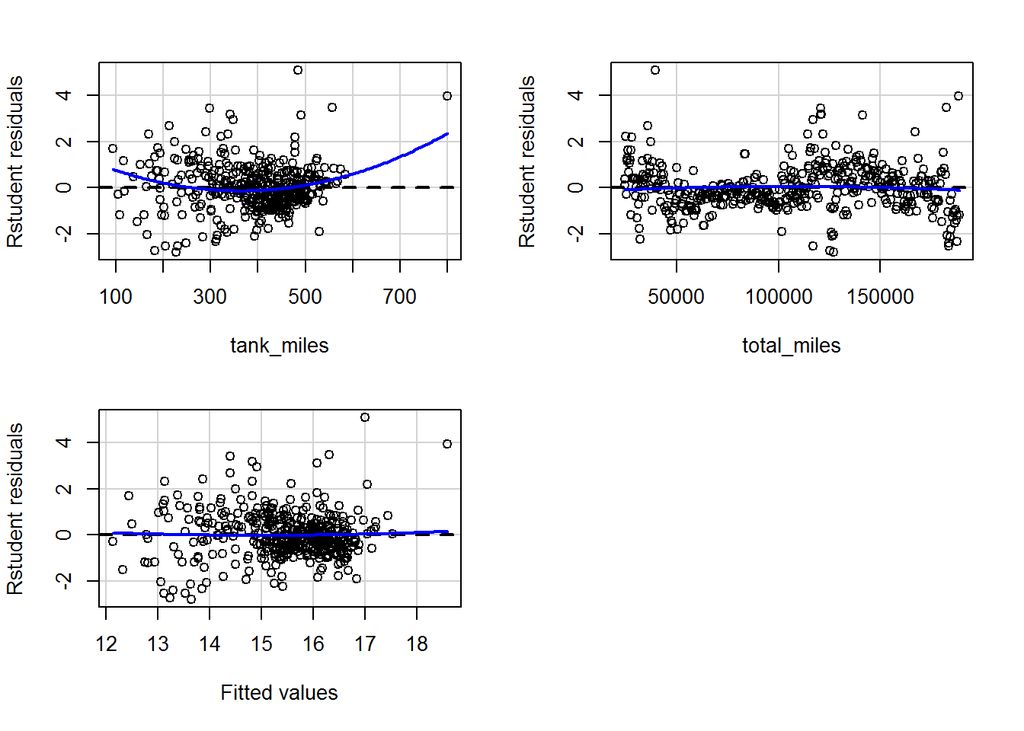

```
##             Test stat Pr(>|Test stat|)
## tank_miles     3.9670       0.00008572 ***
## total_miles   -0.9888           0.3233
## Tukey test     0.3304           0.7411
## ---
## Signif. codes:  0 '***' 0.001 '**' 0.01 '*' 0.05 '.' 0.1 ' ' 1
```

```r
library(car)
residualPlots(lin.mod, type = "rstudent")
```

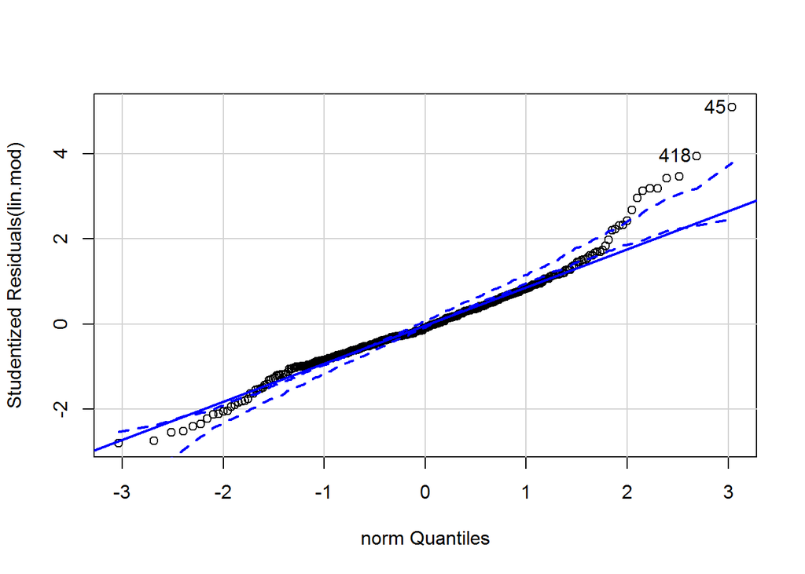

```
## [1]  45 418
```

```r
qqPlot(lin.mod, distribution = "norm")
```

As you can see from our residual plots, we’re pretty happy about heteroscedasticity and normality, but not so much linearity. Lets apply a transformation to the data.

```r
options(scipen = 999) ## to remove scientific notation
lin.mod = lm(mpg~poly(tank_miles,2)+total_miles,data = truck)
summary(lin.mod)
```

```
##
## Call:
## lm(formula = mpg ~ poly(tank_miles, 2) + total_miles, data = truck)
##
## Residuals:
##     Min      1Q  Median      3Q     Max
## -5.3176 -1.0260 -0.1649  0.8991  8.6403
##
## Coefficients:
##                         Estimate  Std. Error t value             Pr(>|t|)
## (Intercept)          16.66044670  0.21400778  77.850 < 0.0000000000000002
## poly(tank_miles, 2)1 19.67470936  1.77098963  11.109 < 0.0000000000000002
## poly(tank_miles, 2)2  7.13725809  1.79914307   3.967        0.00008572038
## total_miles          -0.00001119  0.00000185  -6.048        0.00000000327
##
## (Intercept)          ***
## poly(tank_miles, 2)1 ***
## poly(tank_miles, 2)2 ***
## total_miles          ***
## ---
## Signif. codes:  0 '***' 0.001 '**' 0.01 '*' 0.05 '.' 0.1 ' ' 1
##
## Residual standard error: 1.766 on 415 degrees of freedom
## Multiple R-squared:  0.277,  Adjusted R-squared:  0.2718
## F-statistic: 53.01 on 3 and 415 DF,  p-value: < 0.00000000000000022
```

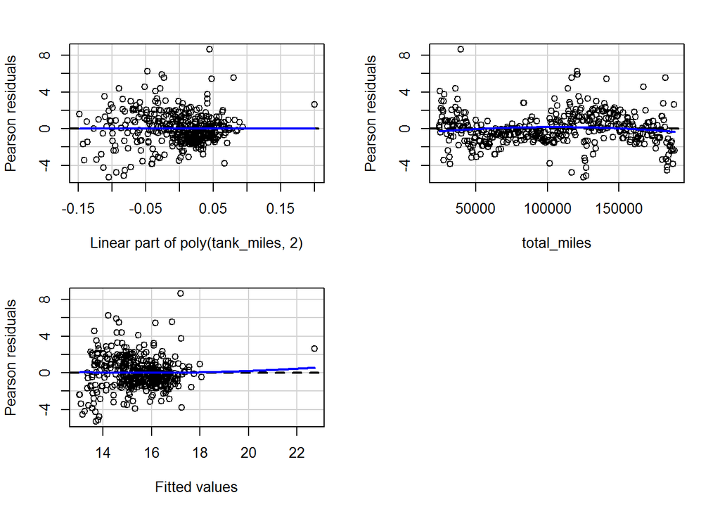

```
##                     Test stat Pr(>|Test stat|)
## poly(tank_miles, 2)
## total_miles           -1.7837          0.07521 .
## Tukey test             0.5390          0.58989
## ---
## Signif. codes:  0 '***' 0.001 '**' 0.01 '*' 0.05 '.' 0.1 ' ' 1
```

```r
residualPlots(lin.mod)
```

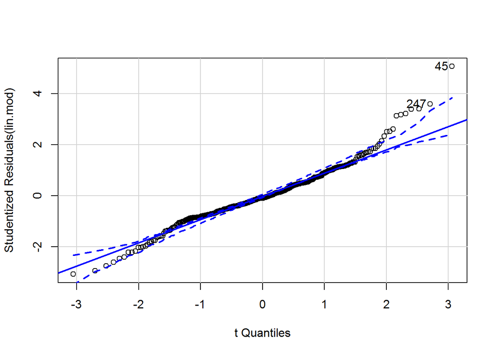

```
## [1]  45 247
```

```r
qqPlot(lin.mod)
```

As you can see, our linearity assumption is now satisfied, however, our since the transformation uses orthogonal polynomials, we lose a little interpretability. We could us the raw data, however, our predictor loses significance.

## Time Series

Since the miles per gallon data was taken on my truck over time, lets to some time series analysis. First, we need to get the data in the correct format.

What I’ll do is rearrange the data so I have a monthly total of gallons I’ve added to my truck.

To do this, I will need to extract the month and year from the dates.

```r
tstruck = truck %>%
  mutate(month = month(fill_up_date)) %>%
  mutate(year = year(fill_up_date))
tstruck %>% select(month, year, gallons)
```

```
## # A tibble: 419 x 3
##    month  year gallons
##    <dbl> <dbl>   <dbl>
##  1     2  2006    22.6
##  2     2  2006    12.8
##  3     2  2006    16.5
##  4     2  2006    24.9
##  5     3  2006    15.8
##  6     3  2006     7.5
##  7     3  2006    18.8
##  8     3  2006    22.1
##  9     3  2006    19
## 10     3  2006    13.7
## # ... with 409 more rows
```

Next I’ll group the data by month and year and summarize the gallons over each month I’ve owned the pickup.

```r
tstruck = tstruck %>%
  group_by(month, year) %>%
  summarise(gallons = sum(gallons)) %>%
  arrange(year, month)
tstruck
```

```
## # A tibble: 131 x 3
## # Groups:   month [12]
##    month  year gallons
##    <dbl> <dbl>   <dbl>
##  1     2  2006    76.8
##  2     3  2006   150.
##  3     4  2006    23.5
##  4     6  2006    23.5
##  5     7  2006    23.5
##  6     9  2006    23.5
##  7    10  2006    42.1
##  8    12  2006    21.9
##  9     1  2007    23.1
## 10     2  2007    20.4
## # ... with 121 more rows
```

What you may notice is that I didn’t fill up my pick up every month. This will cause an issue when it comes to time series analysis because I need an observation for every month. I need to add a `0` for every month that is missing. Here is how I will accomplish this task.

First, I’ll create a tibble of months from when we purchased the pick up until now. I’ll extract out the month and year just like my origional dataset.

```r
startday = mdy("2-2-2006")
endday = mdy("6-2-2018")
helper = tibble(date = startday + months(0:149)) %>%
  mutate(month = month(date)) %>%
  mutate(year = year(date))
helper
```

```
## # A tibble: 150 x 3
##    date       month  year
##    <date>     <dbl> <dbl>
##  1 2006-02-02     2  2006
##  2 2006-03-02     3  2006
##  3 2006-04-02     4  2006
##  4 2006-05-02     5  2006
##  5 2006-06-02     6  2006
##  6 2006-07-02     7  2006
##  7 2006-08-02     8  2006
##  8 2006-09-02     9  2006
##  9 2006-10-02    10  2006
## 10 2006-11-02    11  2006
## # ... with 140 more rows
```

Next, I’ll do a `full_join` of the helper tibble I created with my origional data.

```r
expanded = full_join(helper, tstruck)
expanded
```

```
## # A tibble: 150 x 4
##    date       month  year gallons
##    <date>     <dbl> <dbl>   <dbl>
##  1 2006-02-02     2  2006    76.8
##  2 2006-03-02     3  2006   150.
##  3 2006-04-02     4  2006    23.5
##  4 2006-05-02     5  2006    NA
##  5 2006-06-02     6  2006    23.5
##  6 2006-07-02     7  2006    23.5
##  7 2006-08-02     8  2006    NA
##  8 2006-09-02     9  2006    23.5
##  9 2006-10-02    10  2006    42.1
## 10 2006-11-02    11  2006    NA
## # ... with 140 more rows
```

Notice how this creates a line for every month, but where I was missing gallons data, I have an `NA`.

I will fix this by replacing the `NA`s with `0`s.

```r
expanded =  expanded %>%
  mutate(gallons = ifelse(is.na(gallons),0,gallons)) %>%
  select(gallons)
expanded
```

```
## # A tibble: 150 x 1
##    gallons
##      <dbl>
##  1    76.8
##  2   150.
##  3    23.5
##  4     0
##  5    23.5
##  6    23.5
##  7     0
##  8    23.5
##  9    42.1
## 10     0
## # ... with 140 more rows
```

Now that I have this in the correct format, I need to make it a time series `ts` object.

```r
truckts = expanded  %>%
  ts(start = 06, frequency = 12)
truckts
```

```
##          Jan       Feb       Mar       Apr       May       Jun       Jul
## 6   76.80000 149.70000  23.47119   0.00000  23.47119  23.47119   0.00000
## 7   20.35000   0.00000   0.00000 145.73100 200.75900 279.03920  39.53400
## 8    0.00000 144.53000  55.60000 110.10000  92.40000 108.44000  71.05000
## 9   58.12300  87.96500  86.53400 108.54000 105.97400 146.23000  61.32000
## 10  77.00000  58.72000  59.51000 169.62900  57.19000  92.42000  69.31000
## 11 116.80000 103.10000 104.44000 112.74000  87.42000  89.16000 117.79200
## 12  73.87000  95.31000 126.30000 133.84000 138.17000 130.69900 156.63200
## 13 127.43000  60.77800 114.10000  23.29000   0.00000  28.46138   0.00000
## 14  75.98300  82.44000  90.27000  79.67400 117.72000  66.36000 251.86000
## 15  31.18000  31.20000  64.50000 112.55000   0.00000  92.94000 126.73000
## 16  64.82000  65.85000  33.00000 162.78000  31.42000  33.25000  24.90000
## 17  26.67000  34.25000  28.76000  31.64000  23.19000  30.66000  34.60000
## 18  18.98000   0.00000  31.50000  18.50000   0.00000   0.00000
##          Aug       Sep       Oct       Nov       Dec
## 6   23.47119  42.10000   0.00000  21.85706  23.10403
## 7  140.55800  82.72200  56.85800  31.10000  29.93200
## 8   58.00700  70.11600   0.00000   0.00000   0.00000
## 9  107.75000 118.97000  56.78000  87.56000  56.54000
## 10  46.46000  88.62000  58.93000 104.64000  79.20000
## 11  39.40000 182.91000 107.97000 164.52000  76.33000
## 12 361.84100 197.24000 101.04000  73.15000  92.00000
## 13  22.76000  84.08000 101.81000  52.04000 100.07000
## 14 144.17000  66.79000  92.24000  20.45900  30.56000
## 15  61.27000  64.86900  84.77000  33.49000  66.69000
## 16   0.00000  30.52000  30.82000   0.00000  27.40000
## 17   0.00000  83.60000   0.00000  27.60000  32.00000
## 18
```

```r
class(truckts)
```

```
## [1] "ts"
```

### Stationary

One of the assumptions that I must make is that my time series is stationary. The Dicky-Fuller (ADF) test (from the `tsries` package), tests the null hypothesis that the data is non-stationary. The alternative hypothesis is that the data is staitonary.

```r
library(tseries)
truckts %>% adf.test()
```

```
##
##  Augmented Dickey-Fuller Test
##
## data:  .
## Dickey-Fuller = -3.8064, Lag order = 5, p-value = 0.02063
## alternative hypothesis: stationary
```

From the results, you can see that a low p-value rejects the null hypothesis and allows us to conclude that the data is stationary. Assumption met.

Next, we can look at the seasonality and trend decomposition of our time series data. We’ll do this using the `forecast` package from [Rob Hyndman](https://robjhyndman.com/)

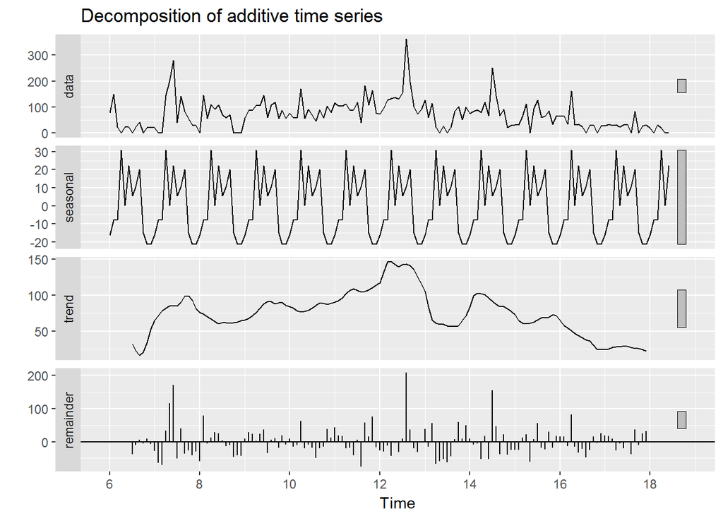

```r
library(forecast)
truckts %>%
  decompose() %>%
  autoplot()
```

You can see below that there is a season aspect and trent component aspect that fluctuates over time.

Because of this, we’ll use the Holt-Winters method to capture seasonality.

```r
mod = truckts %>%
  hw(h=12*13, seasonal = "additive")
summary(mod)
```

```
##
## Forecast method: Holt-Winters' additive method
##
## Model Information:
## Holt-Winters' additive method
##
## Call:
##  hw(y = ., h = 12 * 13, seasonal = "additive")
##
##   Smoothing parameters:
##     alpha = 0.3801
##     beta  = 0.0001
##     gamma = 0.0002
##
##   Initial states:
##     l = 27.7656
##     b = 1.0786
##     s = -19.8683 -18.5304 -13.6281 18.1871 14.8198 6.5703
##            10.4646 -3.4064 30.5586 -6.9658 -6.0757 -12.1257
##
##   sigma:  53.036
##
##      AIC     AICc      BIC
## 1959.967 1964.604 2011.148
##
## Error measures:
##                     ME     RMSE      MAE  MPE MAPE      MASE       ACF1
## Training set -3.231002 50.12765 35.79401 -Inf  Inf 0.6686566 0.04863554
##
## Forecasts:
##        Point Forecast      Lo 80     Hi 80      Lo 95    Hi 95
## Jul 18      11.504752  -56.46359  79.47310  -92.44386 115.4534
## Aug 18      20.777780  -51.93669  93.49225  -90.42941 131.9850
## Sep 18      25.188008  -51.98363 102.35965  -92.83583 143.2119
## Oct 18      -5.606647  -86.99399  75.78069 -130.07784 118.8645
## Nov 18      -9.482025  -94.87936  75.91531 -140.08597 121.1219
## Dec 18      -9.788006  -99.01737  79.44135 -146.25254 126.6765
## Jan 19      -1.010341  -93.91579  91.89511 -143.09696 141.0763
## Feb 19       6.075394  -90.36804 102.51882 -141.42210 153.5729
## Mar 19       6.194326  -93.66366 106.05231 -146.52529 158.9139
```

[output cut: 132 more lines]

```
## Apr 30     180.393061 -139.69650 500.48263 -309.14168 669.9278
## May 30     147.479761 -173.73360 468.69312 -343.77368 638.7332
## Jun 30     162.385923 -159.94791 484.71976 -330.58114 655.3530
## Jul 30     159.497695 -163.95421 482.94960 -335.17930 654.1747
## Aug 30     168.770723 -155.79511 493.33655 -327.60988 665.1513
## Sep 30     173.180951 -152.49558 498.85749 -324.89833 671.2602
## Oct 30     142.386296 -184.39776 469.17035 -357.38678 642.1594
## Nov 30     138.510918 -189.37749 466.39933 -362.95114 639.9730
## Dec 30     138.204936 -190.78471 467.19459 -364.94131 641.3512
## Jan 31     146.982602 -183.10519 477.07039 -357.84311 651.8083
## Feb 31     154.068337 -177.11454 485.25121 -352.43216 660.5688
## Mar 31     154.187269 -178.08766 486.46219 -353.98338 662.3579
## Apr 31     192.725806 -140.63817 526.08978 -317.11040 702.5620
## May 31     159.812506 -174.63755 494.26256 -351.68471 671.3097
## Jun 31     174.718668 -160.81452 510.25186 -338.43506 687.8724
```

It might be interesting to know when my truck will go over 200,000 miles.

Lets extract the predictions.

```r
futurevec = ((mod$upper[,2]-mod$lower[,2])/2)+mod$lower[,2]
uppervec = mod$upper[,1]
futurevec
```

```
##           Jan        Feb        Mar        Apr        May        Jun
## 18
## 19  -1.010341   6.075394   6.194326  44.732864  11.819563  26.725725
## 20  11.322404  18.408139  18.527071  57.065609  24.152308  39.058470
## 21  23.655149  30.740884  30.859816  69.398354  36.485054  51.391216
## 22  35.987894  43.073630  43.192562  81.731099  48.817799  63.723961
## 23  48.320640  55.406375  55.525307  94.063844  61.150544  76.056706
## 24  60.653385  67.739120  67.858052 106.396590  73.483289  88.389451
## 25  72.986130  80.071865  80.190797 118.729335  85.816035 100.722197
## 26  85.318875  92.404611  92.523543 131.062080  98.148780 113.054942
## 27  97.651621 104.737356 104.856288 143.394825 110.481525 125.387687
## 28 109.984366 117.070101 117.189033 155.727571 122.814270 137.720432
## 29 122.317111 129.402846 129.521778 168.060316 135.147015 150.053177
## 30 134.649856 141.735592 141.854523 180.393061 147.479761 162.385923
## 31 146.982602 154.068337 154.187269 192.725806 159.812506 174.718668
##           Jul        Aug        Sep        Oct        Nov        Dec
## 18  11.504752  20.777780  25.188008  -5.606647  -9.482025  -9.788006
## 19  23.837497  33.110526  37.520754   6.726099   2.850720   2.544739
## 20  36.170243  45.443271  49.853499  19.058844  15.183465  14.877484
## 21  48.502988  57.776016  62.186244  31.391589  27.516210  27.210229
## 22  60.835733  70.108761  74.518989  43.724334  39.848956  39.542975
## 23  73.168478  82.441506  86.851735  56.057080  52.181701  51.875720
## 24  85.501224  94.774252  99.184480  68.389825  64.514446  64.208465
## 25  97.833969 107.106997 111.517225  80.722570  76.847191  76.541210
## 26 110.166714 119.439742 123.849970  93.055315  89.179937  88.873955
## 27 122.499459 131.772487 136.182716 105.388061 101.512682 101.206701
## 28 134.832204 144.105233 148.515461 117.720806 113.845427 113.539446
## 29 147.164950 156.437978 160.848206 130.053551 126.178172 125.872191
## 30 159.497695 168.770723 173.180951 142.386296 138.510918 138.204936
## 31
```

```r
uppervec
```

```
##          Jan       Feb       Mar       Apr       May       Jun       Jul
## 18                                                              79.47310
## 19  91.89511 102.51882 106.05231 147.89424 118.18351 136.20029 136.34080
## 20 140.53280 150.20222 152.85652 193.88481 163.41809 180.72989 180.21035
## 21 181.17525 190.40111 192.63300 233.25839 202.40682 219.35051 218.47812
## 22 217.60110 226.55832 228.53084 268.90561 237.81169 254.52086 253.42117
## 23 251.31777 260.09050 261.88354 302.08362 270.81958 287.36302 286.10167
## 24 283.10830 291.74457 293.40421 333.47383 302.08218 318.50075 317.11708
## 25 313.44110 321.97134 323.52698 363.49457 332.00278 348.32306 346.84281
## 26 342.62263 351.06755 352.53929 392.42435 360.85139 377.09181 375.53290
## 27 370.86630 379.24071 380.64299 420.45961 388.81921 404.99316 403.36868
## 28 398.32769 406.64265 407.98627 447.74501 416.04748 432.16504 430.48485
## 29 425.12438 433.38838 434.68165 474.39064 442.64397 458.71296 456.98474
## 30 451.34773 459.56745 460.81693 500.48263 468.69312 484.71976 482.94960
## 31 477.07039 485.25121 486.46219 526.08978 494.26256 510.25186
##          Aug       Sep       Oct       Nov       Dec
## 18  93.49225 102.35965  75.78069  75.91531  79.44135
## 19 148.56235 155.84921 127.86443 126.73670 129.12020
## 20 191.81311 198.51781 169.98398 168.33726 170.22917
## 21 229.74283 236.12300 207.27728 205.33052 206.93351
## 22 264.46582 270.63261 241.57987 239.43214 240.83990
## 23 296.98882 303.00198 273.79931 271.50522 272.77006
## 24 327.88455 333.78050 304.46302 302.05642 303.21098
## 25 357.51552 363.31840 333.90948 331.41304 332.47931
## 26 386.12828 391.85503 362.37117 359.80094 360.79454
## 27 413.89946 419.56252 390.01586 387.38369 388.31620
## 28 440.96069 446.56951 416.96928 414.28422 415.16448
## 29 467.41314 472.97508 443.32851 440.59764 441.43261
## 30 493.33655 498.85749 469.17035 466.39933 467.19459
## 31
```

Then lets create a tibble of dates that we can join our future predictions to.

```r
startday = mdy("6-2-2018")
helper = tibble(date = startday + months(1:length(futurevec))) %>%
  mutate(month = month(date)) %>%
  mutate(year = year(date))
helper
```

```
## # A tibble: 156 x 3
##    date       month  year
##    <date>     <dbl> <dbl>
##  1 2018-07-02     7  2018
##  2 2018-08-02     8  2018
##  3 2018-09-02     9  2018
##  4 2018-10-02    10  2018
##  5 2018-11-02    11  2018
##  6 2018-12-02    12  2018
##  7 2019-01-02     1  2019
##  8 2019-02-02     2  2019
##  9 2019-03-02     3  2019
## 10 2019-04-02     4  2019
## # ... with 146 more rows
```

Now join the prediction.

```r
predictedmiles = data.frame(helper, futurevec = futurevec, uppervec = uppervec) %>%
  select(date, futurevec, uppervec)
head(predictedmiles)
```

```
##         date futurevec  uppervec
## 1 2018-07-02 11.504752  79.47310
## 2 2018-08-02 20.777780  93.49225
## 3 2018-09-02 25.188008 102.35965
## 4 2018-10-02 -5.606647  75.78069
## 5 2018-11-02 -9.482025  75.91531
## 6 2018-12-02 -9.788006  79.44135
```

```r
predictedmiles = predictedmiles %>%
  mutate(accumulatedexpected = cumsum(futurevec), accumulatedearliest = cumsum(uppervec))
head(predictedmiles)
```

```
##         date futurevec  uppervec accumulatedexpected accumulatedearliest
## 1 2018-07-02 11.504752  79.47310            11.50475             79.4731
## 2 2018-08-02 20.777780  93.49225            32.28253            172.9653
## 3 2018-09-02 25.188008 102.35965            57.47054            275.3250
## 4 2018-10-02 -5.606647  75.78069            51.86389            351.1057
## 5 2018-11-02 -9.482025  75.91531            42.38187            427.0210
## 6 2018-12-02 -9.788006  79.44135            32.59386            506.4624
```

Now, lets determine the total miles my truck currently has on it.

```r
currentmiles = truck %>%
  summarise(currentmiles = max(total_miles))
currentmiles$currentmiles
```

```
## [1] 189161.7
```

Now to add in the current miles:

```r
predictedmiles %>%
  mutate(predictedexpected = accumulatedexpected+currentmiles$currentmiles) %>%
  mutate(predictedupperestiment = accumulatedearliest+currentmiles$currentmiles) %>%
  select(date, expected = predictedexpected, earliest = predictedupperestiment) %>%
  filter(earliest>199000&earliest<200500 | expected>199000&expected<200500)
```

```
##          date expected earliest
## 1  2023-02-02 190990.5 199234.9
## 2  2023-03-02 191046.0 199496.8
## 3  2023-04-02 191140.1 199798.9
## 4  2023-05-02 191201.2 200069.7
## 5  2023-06-02 191277.3 200357.1
## 6  2029-08-02 199003.4 227667.6
## 7  2029-09-02 199164.2 228140.6
## 8  2029-10-02 199294.3 228583.9
## 9  2029-11-02 199420.4 229024.5
## 10 2029-12-02 199546.3 229466.0
## 11 2030-01-02 199681.0 229917.3
## 12 2030-02-02 199822.7 230376.9
## 13 2030-03-02 199964.6 230837.7
## 14 2030-04-02 200144.9 231338.2
## 15 2030-05-02 200292.4 231806.9
## 16 2030-06-02 200454.8 232291.6
```